# 本次课我们将学到：

颜色空间的转换，利用颜色信息去理解图像，检测图像中是否包含目标颜色（范围），以及图像的基本运算：

[figure not shown]

## 1. 环境配置

（1）安装Python： https://www.python.org

```
 根据电脑的操作系统选择合适的安装文件下载安装。
```

（2）安装PyCharm（PyCharm Community Edition）： https://www.jetbrains.com/pycharm/download/?section=windows

（3）安装OpenCV库：

- 打开PyCharm，新建一个项目，取名，设置Python解释器；
- 点击菜单File->Setting

[figure not shown]

- 点击 + 安装第三方库

[figure not shown]

- 输入opencv-python，点击安装

[figure not shown]

OpenCV官网及官方文档：

https://github.com/opencv/

https://docs.opencv.org/4.x/

```python
#导入opencv库
import cv2
```

## 2. 图像数据读写及显示

[figure not shown]

读图像API： cv2.imread( filename[, flags= IMREAD_COLOR] ) -> mat 图像/数组对象

常见flags设置：

- cv2.IMREAD_COLOR（1）：always convert image to the 3 channel BGR color image（默认）
- cv2.IMREAD_GRAYSCALE（0）： always convert image to the single channel grayscale image

任何一个API，如果你有疑惑，都建议官网查找函数的相关文档，了解其参数、返回值等。

```python
img=cv2.imread('Images/Child1.jpg')   #不能有中文
```

```python
img
```

```
array([[[225, 224, 220],
        [231, 230, 226],
        [234, 232, 231],
        ...,
        [237, 236, 232],
        [237, 237, 237],
        [227, 227, 227]],

       [[236, 235, 231],
        [233, 232, 228],
        [234, 232, 231],
        ...,
        [237, 236, 232],
        [238, 236, 235],
        [235, 236, 234]],

       [[236, 235, 231],
        [233, 232, 228],
        [236, 233, 229],
        ...,
        [236, 233, 229],
        [237, 234, 230],
        [236, 235, 231]],

       ...,

       [[241, 243, 243],
        [242, 242, 242],
        [240, 238, 237],
        ...,
        [239, 236, 232],
        [240, 236, 235],
        [236, 234, 234]],

       [[230, 237, 234],
        [231, 236, 234],
        [231, 230, 226],
        ...,
        [239, 236, 232],
        [236, 234, 233],
        [231, 232, 230]],

       [[184, 193, 190],
        [192, 198, 193],
        [183, 183, 177],
        ...,
        [237, 234, 229],
        [235, 233, 232],
        [221, 222, 220]]], dtype=uint8)
```

```python
img.shape
```

```
(512, 512, 3)
```

```python
type(img)
```

```
numpy.ndarray
```

```python
img.size
```

```
786432
```

```python
img.dtype
```

```
dtype('uint8')
```

图像显示API： cv2.imshow(winname, mat)

```python
cv2.imshow('Image',img)   #窗口会没响应,挂掉
```

```python
cv2.imshow('Image',img)
cv2.waitKey(0)    #等待按键，waitKey(delay)，如果delay<=0则一直等待按键，如果大于0，则等待delay毫秒
cv2.destroyAllWindows()   #或者destroyWindow('image'),只关闭名字为image的窗口
```

```python
'''按下指定的按键则退出，如q键'''
while True:
    cv2.imshow('Image',img)

    if cv2.waitKey(1) & 0XFF == ord('q'):  #某些系统中，返回的键盘值可能不是ASCII编码的，所以通过与运算只取字符最后一个字节
        break

cv2.destroyAllWindows()
```

```python
'''窗口可放大缩小'''
cv2.namedWindow('Image resize', 0) #0:WINDOW_NORMAL(大小可变),1:WINDOW_AUTOSIZE（大小不可变，默认）
cv2.resizeWindow('Image resize', 512, 512)
cv2.moveWindow('Image resize', 0, 0)

cv2.imshow('Image resize',img)
cv2.waitKey(0)
cv2.destroyAllWindows()
```

```python
img2=cv2.imread('Images/Child1.jpg',cv2.IMREAD_GRAYSCALE)
# img2=cv2.imread('Images/Child1.jpg',0)
img2
```

```
array([[223, 229, 232, ..., 235, 237, 227],
       [234, 231, 232, ..., 235, 236, 235],
       [234, 231, 232, ..., 232, 233, 234],
       ...,
       [243, 242, 238, ..., 235, 236, 234],
       [235, 235, 229, ..., 235, 234, 231],
       [191, 196, 181, ..., 233, 233, 221]], dtype=uint8)
```

```python
img2.shape
```

```
(512, 512)
```

```python
cv2.imshow('gray image',img2)
cv2.waitKey(0)
cv2.destroyAllWindows()
```

```python
def cv_show(name,img): #窗口名字，图像
    cv2.imshow(name,img)
    cv2.waitKey(0)
    cv2.destroyAllWindows()
```

写图像API： cv2.imwrite( filename, img[, params] )

```python
cv2.imwrite('gray child.png',img2)
```

```
True
```

## 3.颜色通道

```python
b,g,r=cv2.split(img)
```

```python
b
```

```
array([[225, 231, 234, ..., 237, 237, 227],
       [236, 233, 234, ..., 237, 238, 235],
       [236, 233, 236, ..., 236, 237, 236],
       ...,
       [241, 242, 240, ..., 239, 240, 236],
       [230, 231, 231, ..., 239, 236, 231],
       [184, 192, 183, ..., 237, 235, 221]], dtype=uint8)
```

```python
b.shape
```

```
(512, 512)
```

```python
cv_show('Blue',b)
```

```python
# 只保留b
img_b = img.copy()
img_b[:,:,1] = 0
img_b[:,:,2] = 0
cv_show('Blue',img_b)
```

```python
# 同理只保留g
img_g = img.copy()
img_g[:,:,0] = 0
img_g[:,:,2] = 0
cv_show('Green',img_g)
```

```python
# 同理只保留r
img_r = img.copy()
img_r[:,:,0] = 0
img_r[:,:,1] = 0
cv_show('Red',img_r)
```

```python
import numpy as np
result = np.hstack([img_b, img_g, img_r])
cv_show('Three channels',result)
```

```python
imgRemerge=cv2.merge((g,r,b))
cv_show('Remerged Image',imgRemerge)
```

## 4. 图像像素或区域(ROI)存取

[figure not shown]

```python
img2
```

```
array([[223, 229, 232, ..., 235, 237, 227],
       [234, 231, 232, ..., 235, 236, 235],
       [234, 231, 232, ..., 232, 233, 234],
       ...,
       [243, 242, 238, ..., 235, 236, 234],
       [235, 235, 229, ..., 235, 234, 231],
       [191, 196, 181, ..., 233, 233, 221]], dtype=uint8)
```

```python
img2[1,2]
```

```
232
```

```python
img2[1,2] = 255  #修改像素值
img2
```

```
array([[223, 229, 232, ..., 235, 237, 227],
       [234, 231, 255, ..., 235, 236, 235],
       [234, 231, 232, ..., 232, 233, 234],
       ...,
       [243, 242, 238, ..., 235, 236, 234],
       [235, 235, 229, ..., 235, 234, 231],
       [191, 196, 181, ..., 233, 233, 221]], dtype=uint8)
```

```python
#彩色图像
img
```

```
array([[[225, 224, 220],
        [231, 230, 226],
        [234, 232, 231],
        ...,
        [237, 236, 232],
        [237, 237, 237],
        [227, 227, 227]],

       [[236, 235, 231],
        [233, 232, 228],
        [234, 232, 231],
        ...,
        [237, 236, 232],
        [238, 236, 235],
        [235, 236, 234]],

       [[236, 235, 231],
        [233, 232, 228],
        [236, 233, 229],
        ...,
        [236, 233, 229],
        [237, 234, 230],
        [236, 235, 231]],

       ...,

       [[241, 243, 243],
        [242, 242, 242],
        [240, 238, 237],
        ...,
        [239, 236, 232],
        [240, 236, 235],
        [236, 234, 234]],

       [[230, 237, 234],
        [231, 236, 234],
        [231, 230, 226],
        ...,
        [239, 236, 232],
        [236, 234, 233],
        [231, 232, 230]],

       [[184, 193, 190],
        [192, 198, 193],
        [183, 183, 177],
        ...,
        [237, 234, 229],
        [235, 233, 232],
        [221, 222, 220]]], dtype=uint8)
```

```python
img[0, 1]
```

```
array([231, 230, 226], dtype=uint8)
```

```python
#进一步分别得到b, g, r值
print('blue:', img[0, 1, 0])
print('green:', img[0, 1, 1])
print('red:', img[0, 1, 2])
```

```
blue: 231
green: 230
red: 226
```

```python
#修改彩色图像像素值
img[0, 1] = [0, 200, 125]
img
```

```
array([[[225, 224, 220],
        [  0, 200, 125],
        [234, 232, 231],
        ...,
        [237, 236, 232],
        [237, 237, 237],
        [227, 227, 227]],

       [[236, 235, 231],
        [233, 232, 228],
        [234, 232, 231],
        ...,
        [237, 236, 232],
        [238, 236, 235],
        [235, 236, 234]],

       [[236, 235, 231],
        [233, 232, 228],
        [236, 233, 229],
        ...,
        [236, 233, 229],
        [237, 234, 230],
        [236, 235, 231]],

       ...,

       [[241, 243, 243],
        [242, 242, 242],
        [240, 238, 237],
        ...,
        [239, 236, 232],
        [240, 236, 235],
        [236, 234, 234]],

       [[230, 237, 234],
        [231, 236, 234],
        [231, 230, 226],
        ...,
        [239, 236, 232],
        [236, 234, 233],
        [231, 232, 230]],

       [[184, 193, 190],
        [192, 198, 193],
        [183, 183, 177],
        ...,
        [237, 234, 229],
        [235, 233, 232],
        [221, 222, 220]]], dtype=uint8)
```

```python
#只修改彩色图像某个像素的某个通道值，如blue通道值
img[0, 1, 0] = 100
```

```python
#获取区域
roi=img[100:450,120:400]
cv_show('ROI',roi)
```

```python
#修改区域
img[100:450,120:400] = [125,255,100]
cv_show('Changed Image',img)
```

## 5.鼠标事件

API：cv2.setMouseCallback(winname, onMouse)

winname：窗口名字

onMouse：回调函数

https://docs.opencv.org/4.x/db/d5b/tutorial_py_mouse_handling.html

```python
'''鼠标拾取颜色'''
import numpy as np

img = cv2.imread('Images/Child1.jpg')
colorList = [] #用于存储鼠标拾取的所有像素点的像素值

#事件类型，鼠标位置x，y，鼠标左、中、右键以及Shift、Ctrl、Alt键是否被按下指示器，其他参数
def pointColor(event,x,y,flags,params):
    if event == cv2.EVENT_LBUTTONDOWN:
        color = img[y,x] #注意坐标系不同
        print(color)
        colorList.append(color)

while True:
    cv2.imshow('Image',img)
    cv2.setMouseCallback('Image',pointColor) #窗口名字，回调函数

    if cv2.waitKey(1) == ord('q'):
        colorArray = np.array(colorList).reshape((-1,3))
        print("*************************")
        print(colorArray.min(axis = 0))
        print(colorArray.max(axis = 0))
        break

cv2.destroyAllWindows()
```

```
[171 185 244]
[153 171 230]
[180 192 246]
[162 177 233]
[173 193 234]
[190 204 240]
[158 177 220]
[188 199 237]
[191 203 243]
[191 202 240]
[184 203 241]
[148 168 225]
[137 161 215]
[137 161 215]
[191 204 246]
```

```python
'''判断每一个像素颜色是否在给定范围内'''
min_BGR = np.array([137, 161, 215], dtype = "uint8")
max_BGR = np.array([191, 204, 246], dtype = "uint8")
mask = cv2.inRange(img, min_BGR, max_BGR)
cv_show('Mask',mask)
mask
```

```
array([[0, 0, 0, ..., 0, 0, 0],
       [0, 0, 0, ..., 0, 0, 0],
       [0, 0, 0, ..., 0, 0, 0],
       ...,
       [0, 0, 0, ..., 0, 0, 0],
       [0, 0, 0, ..., 0, 0, 0],
       [0, 0, 0, ..., 0, 0, 0]], dtype=uint8)
```

## 6.滑动条的创建和使用

API：

- cv2.createTrackbar(trackbarname, winname, value, count, onChange)：创建一个滑动条，参数分别为：滑动条名称，所在窗口名称，初始值，最大值（最小值都是0），回调函数
- cv2.getTrackbarPos(trackbarname, winname)：获得滑动条的当前值，参数分别为：滑动条名称，所在窗口名称

https://docs.opencv.org/4.x/d7/dfc/group__highgui.html

```python
'''创建滑动条，通过滑动条动态调整颜色范围'''
import cv2
import numpy as np

img=cv2.imread("Images/Child1.jpg")

def empty(a):
    pass

cv2.namedWindow("BGR")
cv2.resizeWindow("BGR", 640, 240)
cv2.createTrackbar("B Min", "BGR", 0, 255, empty) #滑动条名称，所在窗口名称，初始值，最大值，回调函数
cv2.createTrackbar("B Max", "BGR", 255, 255, empty)
cv2.createTrackbar("G Min", "BGR", 0, 255, empty)
cv2.createTrackbar("G Max", "BGR", 255, 255, empty)
cv2.createTrackbar("R Min", "BGR", 0, 255, empty)
cv2.createTrackbar("R Max", "BGR", 255, 255, empty)

while True:
    b_min = cv2.getTrackbarPos("B Min", "BGR") #滑动条名称，窗口名称
    b_max = cv2.getTrackbarPos("B Max", "BGR")
    g_min = cv2.getTrackbarPos("G Min", "BGR")
    g_max = cv2.getTrackbarPos("G Max", "BGR")
    r_min = cv2.getTrackbarPos("R Min", "BGR")
    r_max = cv2.getTrackbarPos("R Max", "BGR")

    lower = np.array([b_min, g_min, r_min])
    upper = np.array([b_max, g_max, r_max])
    mask = cv2.inRange(img, lower, upper)
    cv2.imshow('Mask',mask)

    if cv2.waitKey(1) == ord('q'):
        break

cv2.destroyAllWindows()
```

## 7.颜色空间

OpenCV支持很多颜色空间（彩色空间、彩色模型），常见的有RGB、GRAY、 HSV（HSB）、HSI、CMYK、Lab等。

[figure not shown]

可利用Photoshop等软件比较一下各种颜色空间。

[video not shown]

不同颜色空间转换API： cv2.cvtColor( src, code[, dst[, dstCn]] ) -> dst

参数code的常用取值：

[figure not shown]

```python
cv2.imshow("Original Image", img)

img_gray=cv2.cvtColor(img, cv2.COLOR_BGR2GRAY)
cv_show("Gray Image", img_gray)
```

```python
cv2.imshow("Original Image", img)

img_hsv=cv2.cvtColor(img, cv2.COLOR_BGR2HSV)
cv_show("HSV Image", img_hsv)
```

```python
'''转换到HSV颜色空间后，通过滑动条动态调整HSV范围'''
import cv2
import numpy as np

img=cv2.imread("Images/Child1.jpg")
img_hsv = cv2.cvtColor(img, cv2.COLOR_BGR2HSV)

def empty(a):
    pass

cv2.namedWindow("HSV")
cv2.resizeWindow("HSV", 640, 240)
cv2.createTrackbar("H Min", "HSV", 0, 180, empty) #滑动条名称，所在窗口名称，初始值，最大值，回调函数
cv2.createTrackbar("H Max", "HSV", 180, 180, empty)
cv2.createTrackbar("S Min", "HSV", 0, 255, empty)
cv2.createTrackbar("S Max", "HSV", 255, 255, empty)
cv2.createTrackbar("V Min", "HSV", 0, 255, empty)
cv2.createTrackbar("V Max", "HSV", 255, 255, empty)

while True:
    h_min = cv2.getTrackbarPos("H Min", "HSV") #滑动条名称，窗口名称
    h_max = cv2.getTrackbarPos("H Max", "HSV")
    s_min = cv2.getTrackbarPos("S Min", "HSV")
    s_max = cv2.getTrackbarPos("S Max", "HSV")
    v_min = cv2.getTrackbarPos("V Min", "HSV")
    v_max = cv2.getTrackbarPos("V Max", "HSV")

    lower = np.array([h_min, s_min, v_min])
    upper = np.array([h_max, s_max, v_max])
    mask = cv2.inRange(img_hsv, lower, upper)
    cv2.imshow('Mask',mask)

    if cv2.waitKey(1) == ord('q'):
        break

cv2.destroyAllWindows()
```

```python
lower = np.array([0, 31, 173], dtype = "uint8")
upper = np.array([78, 255, 255], dtype = "uint8")
mask = cv2.inRange(img_hsv, lower, upper)
cv_show('Mask',mask)
mask
```

```
array([[0, 0, 0, ..., 0, 0, 0],
       [0, 0, 0, ..., 0, 0, 0],
       [0, 0, 0, ..., 0, 0, 0],
       ...,
       [0, 0, 0, ..., 0, 0, 0],
       [0, 0, 0, ..., 0, 0, 0],
       [0, 0, 0, ..., 0, 0, 0]], dtype=uint8)
```

```python
#只关注ROI
roi_img = img[250:260,250:260]
roi_hsv = cv2.cvtColor(roi_img, cv2.COLOR_BGR2HSV)
roi_mask = cv2.inRange(roi_hsv, lower, upper)
roi_mask
```

```
array([[255, 255, 255, 255, 255, 255, 255, 255, 255, 255],
       [255, 255, 255, 255, 255, 255, 255, 255, 255, 255],
       [255, 255, 255, 255, 255, 255, 255, 255, 255, 255],
       [255, 255, 255, 255, 255, 255, 255, 255, 255, 255],
       [255, 255, 255, 255, 255, 255, 255, 255, 255, 255],
       [255, 255, 255, 255, 255, 255, 255, 255, 255, 255],
       [255, 255, 255, 255, 255, 255, 255, 255, 255, 255],
       [255, 255, 255, 255, 255, 255, 255, 255, 255, 255],
       [255, 255, 255, 255, 255, 255, 255, 255, 255, 255],
       [255, 255, 255, 255, 255, 255, 255, 255, 255, 255]], dtype=uint8)
```

```python
#是否检测到肤色
#判断mask每个像素是否等于255
mask==255
```

```
array([[False, False, False, ..., False, False, False],
       [False, False, False, ..., False, False, False],
       [False, False, False, ..., False, False, False],
       ...,
       [False, False, False, ..., False, False, False],
       [False, False, False, ..., False, False, False],
       [False, False, False, ..., False, False, False]])
```

```python
(mask==255).any() #只要有一个像素为255结果就为True
```

```
True
```

```python
(mask==255).all() #所有像素都等于255结果才为True
```

```
False
```

```python
#检测出来的区域在整个图像的占比
(mask==255).sum()/(mask.shape[0]*mask.shape[1])
```

```
0.3264503479003906
```

```python
#ROI 同理
roi_mask==255
```

```
array([[ True,  True,  True,  True,  True,  True,  True,  True,  True,
         True],
       [ True,  True,  True,  True,  True,  True,  True,  True,  True,
         True],
       [ True,  True,  True,  True,  True,  True,  True,  True,  True,
         True],
       [ True,  True,  True,  True,  True,  True,  True,  True,  True,
         True],
       [ True,  True,  True,  True,  True,  True,  True,  True,  True,
         True],
       [ True,  True,  True,  True,  True,  True,  True,  True,  True,
         True],
       [ True,  True,  True,  True,  True,  True,  True,  True,  True,
         True],
       [ True,  True,  True,  True,  True,  True,  True,  True,  True,
         True],
       [ True,  True,  True,  True,  True,  True,  True,  True,  True,
         True],
       [ True,  True,  True,  True,  True,  True,  True,  True,  True,
         True]])
```

```python
(roi_mask==255).any()
```

```
True
```

```python
(roi_mask==255).all()
```

```
True
```

```python
#感兴趣区域内对应的占比
(roi_mask==255).sum()/(roi_mask.shape[0]*roi_mask.shape[1])
```

```
1.0
```

## 8.图像位运算

### 8.1 掩码（mask）

[figure not shown]

单通道图像，同时是二值图像（像素值要么为0，要么为255），主要起屏蔽作用，让我们只关注感兴趣区域，即仅让掩膜中的白色区域参与计算，屏蔽黑色部分。

### 8.2 位运算

与、或、异或、非

[figure not shown]

对应的API分别为：

- cv2.bitwise_and(src1, src2[, dst[, mask]])
- cv2.bitwise_or(src1, src2[, dst[, mask]])
- cv.bitwise_xor(src1, src2[, dst[, mask]])
- cv2.bitwise_not(src[, dst[, mask]])

注意，src1和src2的shape要一样才能进行计算，除非其中一个为标量。

此外，调用这些函数时，如果设置了mask，则只在mask不为0的区域进行位运算；否则所有区域进行运算。

```python
import cv2
img=cv2.imread('Images/Circle.png')
cv2.imshow('Image1',img)

img2=cv2.imread('Images/Rectangle.png')
h,w,c = img.shape
img2 = cv2.resize(img2, (w,h)) #缩放图像，使图像大小为w*h
cv_show('Image2',img2)
```

```python
result_and = cv2.bitwise_and(img, img2)
cv2.imshow('And',result_and)

result_or = cv2.bitwise_or(img, img2)
cv2.imshow('Or',result_or)

result_xor = cv2.bitwise_xor(img, img2)
cv_show('Xor',result_xor)
```

```python
#通过mask取出感兴趣区域
img=cv2.imread("Images/Child1.jpg")

roi = cv2.bitwise_and(img, img, mask = mask)
cv_show('ROI',roi)
```

```python
#取出背景区域
maskInv = cv2.bitwise_not(mask)
cv2.imshow('Mask Inverse', maskInv)

roiInv = cv2.bitwise_and(img, img, mask = maskInv)
cv_show('Back ground',roiInv)
```

## 9.图像相加和融合

参考文档：https://docs.opencv.org/4.x/d0/d86/tutorial_py_image_arithmetics.html

### 9.1 图像相加

```python
img2=cv2.imread("Images/Child2.png")
h,w,c = img.shape
img2 = cv2.resize(img2, (w,h)) #缩放图像，使图像大小同img一致

cv2.imshow('Image1',img)
cv2.imshow('Image2',img2)

img_add = img + img2
cv_show('imgAdd',img_add)
```

```python
print(img[:1,:10,0])
print('----------------------------')
print(img2[:1,:10,0])
print('----------------------------')
print(img_add[:1,:10,0]) # 和 %256
```

```
[[225 231 234 234 231 232 234 233 233 230]]
----------------------------
[[238 237 238 240 239 238 236 234 233 236]]
----------------------------
[[207 212 216 218 214 214 214 211 210 210]]
```

#### 图像相加API: cv.add( src1, src2[, dst[, mask[, dtype]]] ) -> dst

```python
img_add2 = cv2.add(img, img2)
print(img_add2[:1,:10,0])  # >255  -> 255
cv_show('imgAdd',img_add2)
```

```
[[255 255 255 255 255 255 255 255 255 255]]
```

同样，图像相减：img-img2 与cv2.subtract(img,img2)也是有区别的，

前者如果差值小于0，会加上256转成正数；后者如果差值小于0，则值为0。

另外，如果要求两幅图像的绝对差，用cv2.absdiff(img, img2)

### 9.2 图像融合

cv2.addWeighted( src1, alpha, src2, beta, gamma[, dst[, dtype]] ) -> dst

```python
# dst = src1∗alpha + src2∗beta  +gamma
dst = cv2.addWeighted(img, 0.4, img2, 0.6, 0) #src1, alpha, src2, beta, gamma
cv_show('Blend Image',dst)
```

#### 演示案例：编程实现镂空拍照

```python
#拍照背景
img = cv2.imread('Images/Space.jpg')
img_roi = img[90:160, 400:485]
cv2.imshow('Image1',img)
cv_show('Image1 ROI',img_roi)
```

```python
#人物
img2 = cv2.imread('Images/Child1.jpg')
img2_roi = img2[0:480, 75:455]
h,w,c = img_roi.shape
img2_roi = cv2.resize(img2_roi, (w,h)) #缩放图像，使两个ROI图像大小一样
cv_show('Image2 ROI',img2_roi)
```

```python
#检测肤色(头发也包含)，获得mask_roi
img2_roi_hsv = cv2.cvtColor(img2_roi, cv2.COLOR_BGR2HSV)
lower = np.array([0, 6, 0], dtype = "uint8")
upper = np.array([26, 255, 255], dtype = "uint8")
mask_roi = cv2.inRange(img2_roi_hsv, lower, upper)
cv_show('Mask ROI', mask_roi)
```

```python
#提取roi的前景
foreground = cv2.bitwise_and(img2_roi, img2_roi, mask = mask_roi)
cv_show('Foreground', foreground)
```

```python
#提取roi的背景
mask_roi_inv = cv2.bitwise_not(mask_roi)
cv2.imshow('Mask ROI Inverse', mask_roi_inv)
background = cv2.bitwise_and(img_roi, img_roi, mask = mask_roi_inv)
cv_show('Background', background)
```

```python
#前景和背景相加
roi_add = cv2.add(foreground, background)
cv2.imshow('roi_add', roi_add)

#最终结果
img[90:160, 400:485] = roi_add
cv_show('Final result', img)
```

更多拍照效果：

[figure not shown]

## 10.视频或摄像头读写

官方文档：https://docs.opencv.org/4.x/dd/d43/tutorial_py_video_display.html

读视频API：cv2.VideoCapture(index/filename)

- 可以捕获摄像头，用数字来控制不同的设备，例如0,1。
- 如果是视频文件，直接指定好路径即可。

```python
cap = cv2.VideoCapture('Images/Dance.mp4')
```

```python
cap.isOpened()
```

```
True
```

```python
ret, frame = cap.read()  #ret是布尔值，表示是否获取成功，frame是一帧图像
print(ret)
frame
```

```
True
```

```
array([[[ 0,  0,  0],
        [ 0,  0,  0],
        [ 1,  1,  0],
        ...,
        [42, 37, 36],
        [42, 37, 36],
        [42, 37, 36]],

       [[ 0,  0,  0],
        [ 0,  0,  0],
        [ 0,  0,  0],
        ...,
        [42, 37, 36],
        [42, 37, 36],
        [42, 37, 36]],

       [[ 1,  1,  0],
        [ 0,  0,  0],
        [ 0,  0,  0],
        ...,
        [42, 37, 36],
        [42, 37, 36],
        [42, 37, 36]],

       ...,

       [[28, 23, 22],
        [28, 23, 22],
        [28, 23, 22],
        ...,
        [47, 44, 45],
        [47, 44, 45],
        [47, 44, 45]],

       [[28, 23, 22],
        [28, 23, 22],
        [28, 23, 22],
        ...,
        [47, 44, 45],
        [47, 44, 45],
        [47, 44, 45]],

       [[28, 23, 22],
        [28, 23, 22],
        [28, 23, 22],
        ...,
        [45, 42, 43],
        [45, 42, 43],
        [45, 42, 43]]], dtype=uint8)
```

```python
cv_show('frame',frame)
```

```python
'''读取视频文件的完整代码示例'''
import cv2
cap = cv2.VideoCapture('Images/Dance.mp4')
while cap.isOpened():
    ret, frame = cap.read() # if frame is read correctly ret is True
    if not ret:
        print("stream end? Exiting ...")
        break

    # Display the frame
    cv2.imshow('frame', frame)
    if cv2.waitKey(1) == ord('q'):
        break
cap.release()   #Closes video file
cv2.destroyAllWindows()
```

```
stream end? Exiting ...
```

```python
'''对视频中的每一帧图像检测肤色'''
import cv2
cap = cv2.VideoCapture('Images/Dance.mp4')
while cap.isOpened():
    ret, frame = cap.read() # if frame is read correctly ret is True
    if not ret:
        print("stream end? Exiting ...")
        break

    # Display the frame
    cv2.imshow('frame', frame)

    #对每一帧图像做处理
    img_hsv = cv2.cvtColor(frame, cv2.COLOR_BGR2HSV)
    mask = cv2.inRange(img_hsv, lower, upper)

    cv2.imshow('mask', mask)

    if cv2.waitKey(1) == ord('q'):
        break
cap.release()   #Closes video file
cv2.destroyAllWindows()
```

```
stream end? Exiting ...
```

```python
'''读取摄像头代码示例'''
import cv2
cap = cv2.VideoCapture(0)
if not cap.isOpened():
    print("Cannot open camera")
    exit()
while True:
    # Capture frame-by-frame
    ret, frame = cap.read()
    # if frame is read correctly ret is True
    if not ret:
        print("Can't receive frame, Exiting ...")
        break

    # Display the frame
    cv2.imshow('frame', frame)
    if cv2.waitKey(1) == 27:  #Esc键是27
        break
# When everything done, Closes capturing device
cap.release()
cv2.destroyAllWindows()
```

设置摄像头画面的分辨率（宽度、高度），帧率等属性：

cv2.VideoCapture.set(propId, value)

获取摄像头属性：

cv.VideoCapture.get(propId)

https://docs.opencv.org/4.x/d4/d15/group__videoio__flags__base.html#gaeb8dd9c89c10a5c63c139bf7c4f5704d

```python
'''设置/获取摄像头属性代码示例'''
import cv2
cap = cv2.VideoCapture(0)

cap.set(cv2.CAP_PROP_FRAME_WIDTH, 1280)  #设置画面宽度，可以简写为cap.set(3, 1280)
cap.set(cv2.CAP_PROP_FRAME_HEIGHT, 720)  #设置画面高度，可以简写为cap.set(4, 720)
cap.set(cv2.CAP_PROP_FPS, 10)  #设置帧率，可以简写为cap.set(5, 10)

print('Width:', cap.get(cv2.CAP_PROP_FRAME_WIDTH))  #获得画面宽度，可以简写为cap.get(3)
print('Height:', cap.get(cv2.CAP_PROP_FRAME_HEIGHT))  #获得画面高度，可以简写为cap.get(4)
print('FPS:', cap.get(cv2.CAP_PROP_FPS))  #获得帧率，可以简写为cap.get(5)

if not cap.isOpened():
    print("Cannot open camera")
    exit()
while True:
    # Capture frame-by-frame
    ret, frame = cap.read()
    # if frame is read correctly ret is True
    if not ret:
        print("Can't receive frame, Exiting ...")
        break

    # Display the frame
    cv2.imshow('frame', frame)
    if cv2.waitKey(1) == 27:  #Esc键是27
        break
# When everything done, Closes capturing device
cap.release()
cv2.destroyAllWindows()
```

```
Width: 1280.0
Height: 720.0
FPS: 10.0
```

```python
'''把摄像头获取的视频流保存为一个文件的代码示例'''
import cv2
cap = cv2.VideoCapture(0)

# Define the codec and create VideoWriter object
fourcc = cv2.VideoWriter.fourcc(*'DIVX')  #https://fourcc.org/codecs.php
out = cv2.VideoWriter('Output.avi', fourcc, 20.0, (640,  480)) #filename, fourcc, fps, frameSize

while cap.isOpened():
    ret, frame = cap.read()
    if not ret:
        print("Can't receive frame (stream end?). Exiting ...")
        break

    # write the frame
    out.write(frame)
    cv2.imshow('frame', frame)
    if cv2.waitKey(1) == ord('q'):
        break
# Release everything if job is finished
cap.release()
out.release()
cv2.destroyAllWindows()
```

## 作业：

利用今天所学知识实现对传输带中不同颜色物体自动计数。

[video not shown]

进阶版：

[video not shown]

提示：

（1）先分别获得每一种目标颜色对应的hsv的范围值，实现时结合读取摄像头代码和通过滑动条动态调整HSV范围代码

[video not shown]

（2）取一个ROI，通过ROI中是否有目标颜色来进行计数；

（3）计数规则：ROI中出现目标颜色到没有目标颜色记一次数。

[figure not shown]

#### 在图像上写文字：

API：

cv.putText(img, text, org, fontFace, fontScale, color[, thickness[, lineType[, bottomLeftOrigin]]])

```
    图像, 文字, 位置, 字体,  缩放, 颜色,  字体粗细
```

```python
import cv2
img=cv2.imread('Images/Child1.jpg')
red_num = yellow_num = 0
cv2.putText(img,'Red: {}   Yellow: {}'.format(red_num, yellow_num),(20,50), cv2.FONT_HERSHEY_SIMPLEX,1.2,(0,125,255),3)
cv_show('Frame', img)
```

## 兴趣拓展

[figure not shown]

https://www.bilibili.com/video/BV1954y1Q77W?spm_id_from=333.788.recommend_more_video.16&vd_source=a6e8ed60496342db4cb41bb3727806f3

https://www.bilibili.com/video/BV1Sa4y1q7XB/?spm_id_from=333.337.search-card.all.click&vd_source=a6e8ed60496342db4cb41bb3727806f3

https://www.bilibili.com/video/BV1tw411E72s/?spm_id_from=333.999.0.0&vd_source=a6e8ed60496342db4cb41bb3727806f3

### 在希冀平台云实验Jupyter notebook中嵌入地显示图像/视频

#### 图像

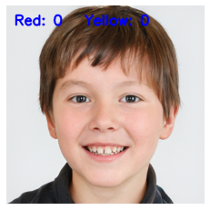

```python
import cv2
import matplotlib.pyplot as plt

img=cv2.imread('Images/Child1.jpg')
red_num = yellow_num = 0
cv2.putText(img,'Red: {}   Yellow: {}'.format(red_num, yellow_num),(20,50), cv2.FONT_HERSHEY_SIMPLEX,1.2,(255,0,0),3)

plt.imshow(cv2.cvtColor(img, cv2.COLOR_BGR2RGB)) #记得BGR转RGB
plt.axis("off")
plt.show()
```

#### 视频

```python
from IPython.display import clear_output, Image, display, HTML
import cv2
import matplotlib.pyplot as plt

#opencv图像转成display的Image
def cv2Image(imageArray):
    ret, png = cv2.imencode('.png', imageArray)
    return Image(data =png, format = 'png' )

cap = cv2.VideoCapture('Images/Dance.mp4')
while cap.isOpened():
    clear_output(wait=True)  #清除上一张图像
    ret, frame = cap.read() # if frame is read correctly ret is True
    if not ret:
        print("stream end? Exiting ...")
        break

    # Display the frame
    img = cv2Image(frame)
    display(img)

cap.release()   #Closes video file
```

```
stream end? Exiting ...
```